# Storm Data Analysis 1950-2011

Susan Lively Klug

August 20, 2015

# Storm Data Analysis

### Answering the questions

1. Across the United States, which types of events are most harmful with respect to population health?
2. Across the United States, which types of events have the greatest economic consequences?

## Data Processing

Original data and documentation locations as of 8/20/2015

https://d396qusza40orc.cloudfront.net/repdata%2Fdata%2FStormData.csv.bz2 https://d396qusza40orc.cloudfront.net/repdata%2Fpeer2_doc%2Fpd01016005curr.pdf https://d396qusza40orc.cloudfront.net/repdata%2Fpeer2_doc%2FNCDC%20Storm%20Events-FAQ%20Page.pdf

Download and read into the raw_data variable. Use cache for this chunk.

```r
if (!file.exists("StormData.csv.bz2")) {
     download.file("http://d396qusza40orc.cloudfront.net/repdata%2Fdata%2FStormData.csv.bz2",
                   "./StormData.csv.bz2")
}

raw_data <- read.csv("StormData.csv.bz2")
```

Investigate choices for defining “most harmful with respect to population health”

```r
library(dplyr)
names(raw_data)
```

```
##  [1] "STATE__"    "BGN_DATE"   "BGN_TIME"   "TIME_ZONE"  "COUNTY"
##  [6] "COUNTYNAME" "STATE"      "EVTYPE"     "BGN_RANGE"  "BGN_AZI"
## [11] "BGN_LOCATI" "END_DATE"   "END_TIME"   "COUNTY_END" "COUNTYENDN"
## [16] "END_RANGE"  "END_AZI"    "END_LOCATI" "LENGTH"     "WIDTH"
## [21] "F"          "MAG"        "FATALITIES" "INJURIES"   "PROPDMG"
## [26] "PROPDMGEXP" "CROPDMG"    "CROPDMGEXP" "WFO"        "STATEOFFIC"
## [31] "ZONENAMES"  "LATITUDE"   "LONGITUDE"  "LATITUDE_E" "LONGITUDE_"
## [36] "REMARKS"    "REFNUM"
```

```r
dim(raw_data)
```

```
## [1] 902297     37
```

```r
type <- unique(raw_data$EVTYPE)
type_df <- data.frame(type)
dim(type_df)
```

```
## [1] 985   1
```

That is a lot of EVTYPEs, 985.  
There are some EVTYPEs with Summaries. These will overlap with the data that they are summarizing, so we filter them out.

```r
tdf <- filter(type_df, !grepl('Summary', type))
dim(tdf)
```

```
## [1] 921   1
```

921 different types is still going to make an unreadable plot, but we only care about the ‘most harmful’ so we can do some elimination of lower ranges once we select the interesting columns.

Except: some of the EVTYPE are mangled and typo issues that should be combined.

“Harmful to the Population Health” in this analysis refers to Fatalities and Injuries to persons. The property or economic damage will be in the second section of the analysis.

From names(raw_data) we know that we are interested in columns “INJURIES” and “FATALITIES” and the columns “EVTYPE”

```r
columns.of.interest = c("EVTYPE", "INJURIES", "FATALITIES")
pop.health <- select(raw_data, one_of(columns.of.interest))
summary(pop.health)
```

```
##                EVTYPE          INJURIES           FATALITIES
##  HAIL             :288661   Min.   :   0.0000   Min.   :  0.0000
##  TSTM WIND        :219940   1st Qu.:   0.0000   1st Qu.:  0.0000
##  THUNDERSTORM WIND: 82563   Median :   0.0000   Median :  0.0000
##  TORNADO          : 60652   Mean   :   0.1557   Mean   :  0.0168
##  FLASH FLOOD      : 54277   3rd Qu.:   0.0000   3rd Qu.:  0.0000
##  FLOOD            : 25326   Max.   :1700.0000   Max.   :583.0000
##  (Other)          :170878
```

We are safe to remove any rows that are zero for both INJURIES and FATALITIES as they will not help us in figuring out the “Maximum Damage” instead of subsetting one could assign them all to the “no damage” category

```r
sum( ( pop.health$INJURIES == 0 ) & ( pop.health$FATALITIES == 0) )
```

```
## [1] 880368
```

```r
pop.health.sm <- filter(pop.health,
             !(( pop.health$INJURIES == 0 ) & ( pop.health$FATALITIES == 0)))
```

Still doesn’t remove many of the EVTYPEs. Some of the EVTYPES are mangled versions of each other and should be combined. We can fix the lower case using toupper from dplyr. There are numerous spelling errors and versions of the same EVTYPE that need to be brute force changed to match.

```r
library(reshape2)
dfn = as.data.frame(sapply(pop.health.sm, toupper))

## S3 method for class 'data.frame'
newdfn <- melt(dfn, id.vars=c("EVTYPE") )
# Need to make them allcaps then more will match with group_by
# In dfn rows with matching EVTYPE and Variable
# should be summed and collapsed.
newdfn$value <- as.integer(newdfn$value)
df <- newdfn %>% group_by(EVTYPE, variable) %>% summarise_each(funs(sum))
df <- df[!(df$value == 0 ), ]
```

Now down to some gritty substituting to get to the valid EVTYPES gsub(pattern, replacement, x)

```r
df$EVTYPE = gsub("AVALANCE", "AVALANCHE", df$EVTYPE)
df$EVTYPE = gsub("WINDS", "WIND", df$EVTYPE)
df$EVTYPE = gsub("LANDSLIDES", "LANDSLIDE", df$EVTYPE)
df$EVTYPE = gsub("SEAS", "SEA", df$EVTYPE)
df$EVTYPE = gsub("ROADS", "ROAD", df$EVTYPE)
df$EVTYPE = gsub("CURRENTS", "CURRENT", df$EVTYPE)

df$EVTYPE = gsub("COASTAL FLOOD.*", "COASTAL FLOOD", df$EVTYPE)
df$EVTYPE = gsub("COASTALSTORM", "COASTAL STORM", df$EVTYPE)
df$EVTYPE = gsub(".*FLASH FLOOD.*", "FLASH FLOOD", df$EVTYPE)
df$EVTYPE = gsub("FLOODING", "FLOOD", df$EVTYPE)
df$EVTYPE = gsub("FLOOD.*", "FLOOD", df$EVTYPE)
df$EVTYPE = gsub("MINOR FLOOD", "FLOOD", df$EVTYPE)
df$EVTYPE = gsub("TIDAL FLOOD", "FLOOD", df$EVTYPE)
df$EVTYPE = gsub("URBAN.* FLOOD", "FLOOD", df$EVTYPE)
df$EVTYPE = gsub("RIVER FLOOD", "FLOOD", df$EVTYPE)
df$EVTYPE = gsub("HIGH WATER", "FLOOD", df$EVTYPE)
df$EVTYPE = gsub("RAPIDLY.*.WATER", "FLOOD", df$EVTYPE)
df$EVTYPE = gsub(".*FLD", "FLOOD", df$EVTYPE)

df$EVTYPE = gsub(".*FIRE.*", "WILDFIRE", df$EVTYPE)
df$EVTYPE = gsub("WILD FIRE", "WILDFIRE", df$EVTYPE)

df$EVTYPE = gsub("RAINS", "RAIN", df$EVTYPE)
df$EVTYPE = gsub("RAINFALL", "RAIN", df$EVTYPE)
df$EVTYPE = gsub("EXCESSIVE RAIN", "HEAVY RAIN", df$EVTYPE)
df$EVTYPE = gsub("TORRENTIAL RAIN", "HEAVY RAIN", df$EVTYPE)

df$EVTYPE = gsub("WINTER WEATHER.*", "WINTER WEATHER", df$EVTYPE)
df$EVTYPE = gsub("RAIN/SNOW", "EXTREME COLD/WIND CHILL", df$EVTYPE)
df$EVTYPE = gsub("GLAZE/ICE STORM", "WINTER STORM", df$EVTYPE)
df$EVTYPE = gsub(".*EXTREME.*CHILL", "EX WIND CHILL", df$EVTYPE)
df$EVTYPE = gsub("EXTREME.*CHILL", "EX WIND CHILL", df$EVTYPE)
df$EVTYPE = gsub("COLD.*", "COLD", df$EVTYPE)
df$EVTYPE = gsub("FOG AND COLD", "FREEZING FOG", df$EVTYPE)
df$EVTYPE = gsub("UNS.*.COLD", "COLD", df$EVTYPE)
df$EVTYPE = gsub("EXT.*.COLD", "EXTREME COLD/WIND CHILL", df$EVTYPE)
df$EVTYPE = gsub("HIGH.*.COLD", "EXTREME COLD/WIND CHILL", df$EVTYPE)
df$EVTYPE = gsub("RECORD.*.COLD", "EXTREME COLD/WIND CHILL", df$EVTYPE)
df$EVTYPE = gsub("SNOW.*.COLD", "EXTREME COLD/WIND CHILL", df$EVTYPE)
df$EVTYPE = gsub("BLACK ICE", "FROST/FREEZE", df$EVTYPE)
df$EVTYPE = gsub("FREEZING DRIZZLE", "FROST/FREEZE", df$EVTYPE)
df$EVTYPE = gsub("FREEZING SPRAY", "FROST/FREEZE", df$EVTYPE)
df$EVTYPE = gsub("FREEZING RAIN", "FROST/FREEZE", df$EVTYPE)
df$EVTYPE = gsub("FREEZE", "FROST/FREEZE", df$EVTYPE)
df$EVTYPE = gsub("FROST", "FROST/FREEZE", df$EVTYPE)
df$EVTYPE = gsub("FROST.*.FREEZE", "FROST/FREEZE", df$EVTYPE)
df$EVTYPE = gsub("ICE STORM", "ICE", df$EVTYPE)
df$EVTYPE = gsub(".*ICE.*", "ICE STORM", df$EVTYPE)
df$EVTYPE = gsub("WINTRY.*", "WINTER WEATHER", df$EVTYPE)
df$EVTYPE = gsub("SNOW.*", "SNOW", df$EVTYPE)
df$EVTYPE = gsub("^SNOW.*", "WINTER STORM", df$EVTYPE)
df$EVTYPE = gsub("LIGHT SNOW.*", "WINTER STORM", df$EVTYPE)
df$EVTYPE = gsub("EX*.SNOW.*", "HEAVY STORM", df$EVTYPE)
df$EVTYPE = gsub("THUNDERSNOW", "HEAVY STORM", df$EVTYPE)
df$EVTYPE = gsub("BLOWING SNOW", "HEAVY STORM", df$EVTYPE)
df$EVTYPE = gsub("EXCESSIVHEAVY STORM", "WINTER STORM", df$EVTYPE)
df$EVTYPE = gsub(".*HAIL.*", "HAIL", df$EVTYPE)
df$EVTYPE = gsub("WINTER STORM.*", "WINTER STORM", df$EVTYPE)
df$EVTYPE = gsub(".*ICY.*", "WINTER WEATHER", df$EVTYPE)
df$EVTYPE = gsub("EX WIND CHILL", "EXTREME COLD/WIND CHILL", df$EVTYPE)

df$EVTYPE = gsub(".*DROUGHT.*", "DROUGHT", df$EVTYPE)
df$EVTYPE = gsub(".*EX.*HEAT", "EXCESSIVE HEAT", df$EVTYPE)
df$EVTYPE = gsub(".*HEAT W.*", "HEAT", df$EVTYPE)
df$EVTYPE = gsub("RECORD HEAT", "HEAT", df$EVTYPE)
df$EVTYPE = gsub(".*WARM.*", "HEAT", df$EVTYPE)

df$EVTYPE = gsub(".*FOG", "DENSE FOG", df$EVTYPE)

df$EVTYPE = gsub(".*RIP CURRENT.*", "RIP CURRENT", df$EVTYPE)
df$EVTYPE = gsub(".*SURF.*", "HIGH SURF", df$EVTYPE)
df$EVTYPE = gsub("STORM SURGE.*", "STORM SURGE", df$EVTYPE)

df$EVTYPE = gsub("WATERSPOUT.*", "WATERSPOUT", df$EVTYPE)
df$EVTYPE = gsub("HIGH WIND.*", "HIGH WIND", df$EVTYPE)
df$EVTYPE = gsub(".*LIGHT.*", "LIGHTNING", df$EVTYPE)
df$EVTYPE = gsub("STORMS", "STORM", df$EVTYPE)
df$EVTYPE = gsub("WIND STORM", "WIND", df$EVTYPE)
df$EVTYPE = gsub("RAIN/WIND", "STRONG WIND", df$EVTYPE)
df$EVTYPE = gsub("TROPICAL STORM.*", "TROPICAL STORM", df$EVTYPE)
df$EVTYPE = gsub("THUNDERST.*", "THUNDERSTORM", df$EVTYPE)
df$EVTYPE = gsub("TSTM", "THUNDERSTORM", df$EVTYPE)
df$EVTYPE = gsub(".*HURRI.*", "HURRICANE", df$EVTYPE)
df$EVTYPE = gsub("WIND.*", "WIND", df$EVTYPE)
df$EVTYPE = gsub(".*TORN.*", "TORNADO", df$EVTYPE)
df$EVTYPE = gsub("MARINE THUNDERSTORM", "MARINE THUNDERSTORM WIND", df$EVTYPE)
df$EVTYPE = gsub("^THUNDERSTORM$", "THUNDERSTORM WIND", df$EVTYPE)
df$EVTYPE = gsub("^THUNDERTORM.*", "THUNDERSTORM WIND", df$EVTYPE)
df$EVTYPE = gsub("WIND WIND", "WIND", df$EVTYPE)
df$EVTYPE = gsub("NON THUNDERSTORM WIND", "HIGH WIND", df$EVTYPE)
df$EVTYPE = gsub("^WIND$", "HIGH WIND", df$EVTYPE)
```

At this point visual inspection shows Tornado at an order of magnitude more damaging than any other event. We might be able to drop the ’1’s

```r
m <- median(df$value)
df <- filter(df, (value > m ) )

# followed by more group and summarise
df <- df %>% group_by(EVTYPE, variable) %>% summarise_each(funs(sum))

unique(df$EVTYPE)
```

```
##  [1] "AVALANCHE"                "BLIZZARD"
##  [3] "COLD"                     "DENSE FOG"
##  [5] "DROUGHT"                  "DRY MICROBURST"
##  [7] "DUST DEVIL"               "DUST STORM"
##  [9] "EXCESSIVE HEAT"           "EXTREME COLD/WIND"
## [11] "FLASH FLOOD"              "FLOOD"
## [13] "FROST/FREEZE"             "GLAZE"
## [15] "GUSTY WIND"               "HAIL"
## [17] "HEAT"                     "HEAVY RAIN"
## [19] "HEAVY SNOW"               "HEAVY STORM"
## [21] "HIGH SEA"                 "HIGH SURF"
## [23] "HIGH WIND"                "HURRICANE"
## [25] "HYPOTHERMIA/EXPOSURE"     "ICE STORM"
## [27] "LANDSLIDE"                "LIGHTNING"
## [29] "LOW TEMPERATURE"          "MARINE MISHAP"
## [31] "MARINE STRONG WIND"       "MARINE THUNDERSTORM WIND"
## [33] "MIXED PRECIP"             "NON-SEVERE WIND"
## [35] "RIP CURRENT"              "ROUGH SEA"
## [37] "STORM SURGE"              "STRONG WIND"
## [39] "THUNDERSTORM WIND"        "TORNADO"
## [41] "TROPICAL STORM"           "TSUNAMI"
## [43] "WATERSPOUT"               "WILDFIRE"
## [45] "WINTER STORM"             "WINTER WEATHER"
```

```r
library(ggplot2)
pop.health <- head(df[order(df$value, decreasing = T), ])
pop.health
```

```
## Source: local data frame [6 x 3]
## Groups: EVTYPE
##
##              EVTYPE   variable value
## 1           TORNADO   INJURIES 91362
## 2 THUNDERSTORM WIND   INJURIES  9402
## 3             FLOOD   INJURIES  6868
## 4    EXCESSIVE HEAT   INJURIES  6680
## 5           TORNADO FATALITIES  5633
## 6         LIGHTNING   INJURIES  5230
```

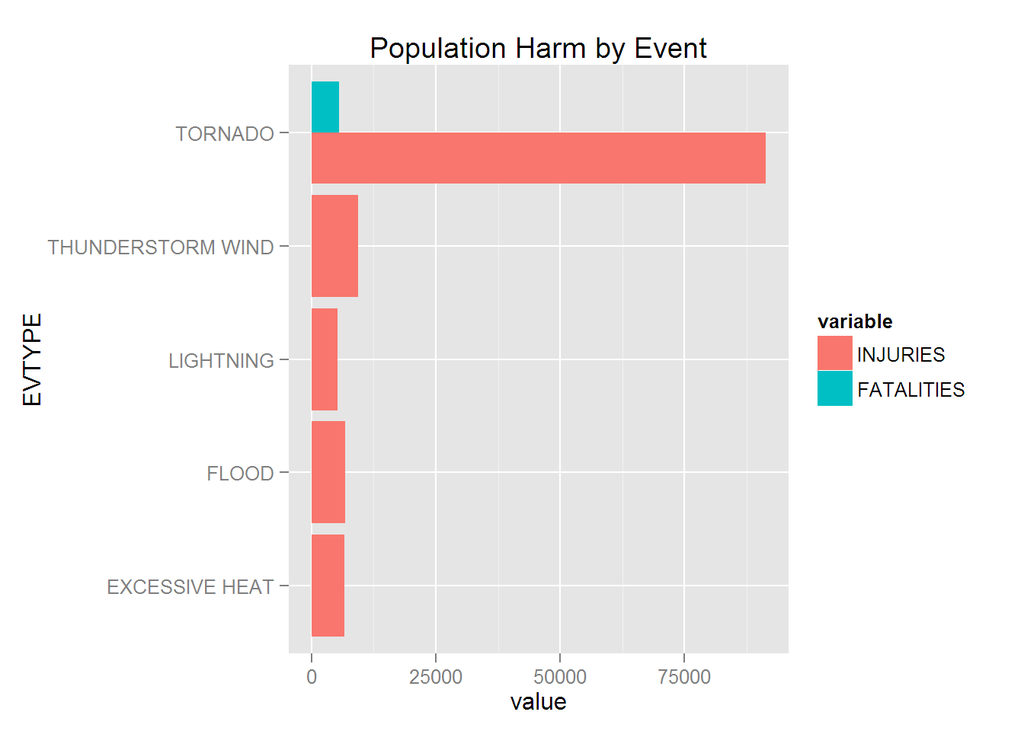

```r
ggplot(pop.health, aes(x=EVTYPE, y=value, fill=variable)) +
     geom_bar(stat="identity", position=position_dodge())+
     ggtitle("Population Harm by Event") +
     coord_flip()
```

## Greatest Economic Consequences

```r
columns.of.interest = c("EVTYPE", "PROPDMG", "PROPDMGEXP")
econ.prop <- select(raw_data, one_of(columns.of.interest))
summary(econ.prop)
```

```
##                EVTYPE          PROPDMG          PROPDMGEXP
##  HAIL             :288661   Min.   :   0.00          :465934
##  TSTM WIND        :219940   1st Qu.:   0.00   K      :424665
##  THUNDERSTORM WIND: 82563   Median :   0.00   M      : 11330
##  TORNADO          : 60652   Mean   :  12.06   0      :   216
##  FLASH FLOOD      : 54277   3rd Qu.:   0.50   B      :    40
##  FLOOD            : 25326   Max.   :5000.00   5      :    28
##  (Other)          :170878                     (Other):    84
```

```r
columns.of.interest = c("EVTYPE", "CROPDMG","CROPDMGEXP")
econ.crop <- select(raw_data, one_of(columns.of.interest))
summary(econ.crop)
```

```
##                EVTYPE          CROPDMG          CROPDMGEXP
##  HAIL             :288661   Min.   :  0.000          :618413
##  TSTM WIND        :219940   1st Qu.:  0.000   K      :281832
##  THUNDERSTORM WIND: 82563   Median :  0.000   M      :  1994
##  TORNADO          : 60652   Mean   :  1.527   k      :    21
##  FLASH FLOOD      : 54277   3rd Qu.:  0.000   0      :    19
##  FLOOD            : 25326   Max.   :990.000   B      :     9
##  (Other)          :170878                     (Other):     9
```

Reviewing the values of expenses related to Property and Crops. PROPDMG is the numeric value of the damage, PROPDMGEXP is the magnitude where ‘B’=billions and the other factors are much smaller.

We can safely view only the ‘B’ cases for crop and property damage.

```r
econ.prop <- filter(econ.prop, PROPDMGEXP=='B')
econ.prop <- select(econ.prop, EVTYPE, PROPDMG)
econ.prop <- econ.prop %>% group_by(EVTYPE) %>% summarise_each(funs(sum))
econ.prop$EVTYPE = gsub(".*HURRI.*", "HURRICANE", econ.prop$EVTYPE)
econ.prop$EVTYPE = gsub(".*TORN.*", "TORNADO", econ.prop$EVTYPE)
econ.prop$EVTYPE = gsub(".*FIRE.*", "WILDFIRE", econ.prop$EVTYPE)

econ.crop <- filter(econ.crop, CROPDMGEXP=='B')
econ.crop <- select(econ.crop, EVTYPE, CROPDMG)
econ.crop <- econ.crop %>% group_by(EVTYPE) %>% summarise_each(funs(sum))

e <- full_join(econ.crop, econ.prop, by="EVTYPE")
```

[figure not shown]

```r
e[is.na(e)] <- 0
e$damages <- e$CROPDMG + e$PROPDMG
e <- arrange(e, desc(damages))
e <- transform(e, EVTYPE = reorder(EVTYPE, damages))
ggplot(e, aes(x=EVTYPE, y=damages)) +
     geom_bar(stat="identity") +
     ggtitle("Economic Damages by Weather Event") +
     coord_flip() +
     labs(x = "Billions of dollars", y = "Event type")
```